# islfd

## Plan

- R Programming
- Probabilidad y Estadística (crash course)
- Aprendizaje Estadístico
- Ejemplo práctico

## R Programming

- Propósito y Task Views
- Instalación de paquetes
- Ayuda
- Tipos de datos
- Tipos de objeto
- Operaciones básicas
- Estructuras de control
- Scope léxico, environments
- Vectorización, funciones anónimas
- Paquetes útiles
- Graficación: ggplot2 y otros

## Propósito y Task Views

R es un lenguaje creado para hacer cómputo estadístico y graficación. Ha sido ampliamente adoptado y extendido por miembros de la comunidad científica, y tiene performance comparable a MATLAB o GNU Octave en cuanto a cómputo con matrices.

La más grande ventaja de R es el acceso a cientos de paquetes a través del [CRAN](https://cran.r-project.org/), con mirrors alrededor del mundo. El CRAN define y mantiene Task Views, listas de paquetes con un propósito en común. También mantiene versiones binarias de muchos paquetes para Windows y OS X.

## Algunas Task Views

- Bayesian Inference
- Clinical Trial Design, Monitoring and Analysis
- Econometrics
- Analysis of Ecological and Environmental Data
- Empirical Finance
- Statistical Genetics
- Natural Language Processing
- Machine Learning & Statistical Learning
- Analysis of Spatial Data
- Graphical Models

[Full list](https://cran.r-project.org/web/views/)

## Instalación de paquetes

Para instalar paquetes del CRAN

```r
install.packages("dplyr")
install.packages("file:///tmp/dplyr.tgz", repos=NULL)
```

Si no hay una versión binaria disponible, `install.packages` compilará las fuentes indicadas, también se encarga de resolver dependencias de paquetes.

Para instalar todos los paquetes en un task view

```r
install.packages("ctv")
library("ctv")
install.views("NaturalLanguageProcessing")
```

## Instalación de paquetes

El paquete `devtools` nos permite instalar un paquete directamente desde su fuente en github, bitbucket, svn, etc.

```r
install.packages("devtools")
library("devtools")
install_github("hadley/ggplot2")
```

El IDE RStudio ofrece una manera sencilla de realizar estas instalaciones, además de ofrecer integración con `packrat`, un paquete que permite aislar el ambiente de R usando una biblioteca privada de paquetes (similar a `virtualenv`).

## Ayuda

R ofrece una manera de acceder a la documentación de una función a través de `?`. Es común que las funciones que un paquete expone estén documentadas, así como encontrar documentación de un paquete en general

```r
?library
?devtools
```

También podemos obtener ayuda acerca de un operador

```r
?`+`
```

## Ayuda

Además, algunos paquetes con funcionalidad compleja ofrecen vignettes, con quickstarts o tutoriales acerca de su uso

```r
vignette(package = "dplyr")
vignette("databases", package = "dplyr")
```

Si todo lo demás falla, existe una comunidad activa en [stack overflow](http://stackoverflow.com/tags/r) para todo lo relacionado con R como lenguaje, así como [cross validated](http://stats.stackexchange.com/) para todas las preguntas de índole estadística.

## Tipos de datos

Existen 6 tipos de datos "atómicos" en R

```r
class(TRUE)
```

```
## [1] "logical"
```

```r
class(42)
```

```
## [1] "numeric"
```

```r
class(42L)
```

```
## [1] "integer"
```

## Tipos de datos

Existen 6 tipos de datos "atómicos" en R

```r
class(4 + 2i)
```

```
## [1] "complex"
```

```r
class("42")
```

```
## [1] "character"
```

```r
class(charToRaw("B"))
```

```
## [1] "raw"
```

## Tipos de datos

Adicionalmente, un factor puede ser usado para expresar variables categóricas. Un factor puede ser ordenado.

```r
class(factor(1))
```

```
## [1] "factor"
```

## Tipos de datos

`NULL` representa al objeto nulo. Indica que un valor o función no está definida

```r
is.null(NULL)
```

```
## [1] TRUE
```

```r
is.null(NA)
```

```
## [1] FALSE
```

```r
1 == NULL
```

```
## logical(0)
```

## Tipos de datos

`NA` representa datos faltantes, es una constante de longitud 1. `NA` puede ser cualquier tipo de dato excepto `raw`. `NA` no es `NULL`, y existen comportamientos predefinidos para lidiar con datos faltantes.

```r
NA + 1
```

```
## [1] NA
```

```r
sum(c(1, 2, 3, NA), na.rm = TRUE)
```

```
## [1] 6
```

```r
na.fail(c(1, 2, 3, NA))
```

```
## Error in na.fail.default(c(1, 2, 3, NA)): missing values in object
```

## Tipos de objeto

Existen muchos tipos de objeto en R, y dos maneras comunes de definir tipos de objeto (clases S3 y S4). Sin embargo, los tipos más comunes son vectores, listas, matrices y data frames.

No existe el tipo de objeto "escalar" en R, el dato atómico es el vector.

```r
length(1)
```

```
## [1] 1
```

## Vectores

Un vector sólo puede contener un tipo de dato. Si un elemento de otro tipo se concatena a un vector, el vector resultante es del tipo más general. La manera más fácil de construir vectores es a través de `c`

```r
c(TRUE, FALSE)
```

```
## [1]  TRUE FALSE
```

```r
c(TRUE, FALSE, 2)
```

```
## [1] 1 0 2
```

```r
c(TRUE, FALSE, 2, "")
```

```
## [1] "TRUE"  "FALSE" "2"     ""
```

## Vectores

Se puede acceder de manera posicional a los elementos de un vector

```r
v <- 10:13
v[[1]]
```

```
## [1] 10
```

```r
v[c(1:2)]
```

```
## [1] 10 11
```

## Vectores

Los elementos de un vector pueden ser nombrados y también accedidos de ese modo

```r
names(v) <- c("uno", "dos", "tres")
v[["uno"]]
```

```
## [1] 10
```

## Listas

Una lista puede contener cualquier tipo de objeto y combinar distintos tipos de datos.

```r
l <- list(1, TRUE, "...")
l
```

```
## [[1]]
## [1] 1
##
## [[2]]
## [1] TRUE
##
## [[3]]
## [1] "..."
```

## Listas

Al igual que un vector, se puede acceder de manera posicional o a través de nombre. A diferencia de un vector, se puede acceder usando el operador `$`

```r
names(l) <- c("uno", "true", "ellipsis")
l$uno
```

```
## [1] 1
```

## Listas

Se pueden borrar elementos de una lista refiriendolos a `NULL`

```r
l$true <- NULL
l
```

```
## $uno
## [1] 1
##
## $ellipsis
## [1] "..."
```

## Matrices

Una matriz es como un vector, aunque con dos dimensiones. Las matrices se llenan y se despliegan en orden de columnas.

```r
m <- matrix(c(1,2,3,4), nrow = 2)
m
```

```
##      [,1] [,2]
## [1,]    1    3
## [2,]    2    4
```

```r
m[1, 2]
```

```
## [1] 3
```

Al igual que un vector, sólo pueden contener un tipo de dato

## Matrices

Las columnas y las filas se pueden nombrar por separado

```r
colnames(m) <- c("col1", "col2")
rownames(m) <- c("row1", "row2")
m
```

```
##      col1 col2
## row1    1    3
## row2    2    4
```

```r
m["row1", "col1"]
```

```
## [1] 1
```

## Matrices

`dim`, `nrow` y `ncol` nos dan las dimensiones de una matriz

```r
dim(m)
```

```
## [1] 2 2
```

```r
nrow(m)
```

```
## [1] 2
```

```r
ncol(m)
```

```
## [1] 2
```

## Data Frames

Un data frame es una colección de variables, que se comporta como matriz o como lista de columnas, según la función que se le aplique.

```r
df <- data.frame(col1 = c(1,2), col2 = c("tres","cuatro"))
df
```

```
##   col1   col2
## 1    1   tres
## 2    2 cuatro
```

Un data frame puede contener distintos tipos de datos

## Data Frames

```r
dim(df)
```

```
## [1] 2 2
```

```r
df$col1
```

```
## [1] 1 2
```

```r
names(df)
```

```
## [1] "col1" "col2"
```

## Factores

Un tipo de objeto adicional es el factor, que sirve para representar variables categóricas, ordenadas o no

```r
f <- factor(c("A veces", "Siempre", "A veces", "Nunca"),
            levels = c("Nunca", "A veces", "Siempre"))
f
```

```
## [1] A veces Siempre A veces Nunca
## Levels: Nunca A veces Siempre
```

```r
as.ordered(f)
```

```
## [1] A veces Siempre A veces Nunca
## Levels: Nunca < A veces < Siempre
```

## Factores

```r
nms <- c("John", "Paul", "George", "Ringo")
df <- data.frame(nombre=nms, sexo=f, stringsAsFactors = F)
df
```

```
##   nombre    sexo
## 1   John A veces
## 2   Paul Siempre
## 3 George A veces
## 4  Ringo   Nunca
```

```r
summary(df)
```

```
##     nombre               sexo
##  Length:4           Nunca  :1
##  Class :character   A veces:2
##  Mode  :character   Siempre:1
```

## Operaciones básicas

```r
7 + 2
```

```
## [1] 9
```

```r
7 - 2
```

```
## [1] 5
```

```r
7 * 2
```

```
## [1] 14
```

## Operaciones básicas

```r
7 / 2
```

```
## [1] 3.5
```

```r
7 %% 2
```

```
## [1] 1
```

```r
7 %/% 2
```

```
## [1] 3
```

## Operaciones básicas

```r
7 / 2
```

```
## [1] 3.5
```

```r
7 ^ 2
```

```
## [1] 49
```

```r
7 ** 2
```

```
## [1] 49
```

## Operaciones básicas

```r
7 %/% 2
```

```
## [1] 3
```

```r
7 %% 2
```

```
## [1] 1
```

## Operaciones básicas

```r
TRUE & FALSE
```

```
## [1] FALSE
```

```r
TRUE | FALSE
```

```
## [1] TRUE
```

```r
!TRUE
```

```
## [1] FALSE
```

## Operaciones básicas

Todas estas operaciones se pueden aplicar a vectores, y se aplicarán componente a componente, repitiendo el vector más pequeño como sea necesario

```r
c(1, 2) + c(3, 0)
```

```
## [1] 4 2
```

```r
c(2, 1) * c(2, 2)
```

```
## [1] 4 2
```

```r
c(1, 2, 3, 4) ^ c(2, 3)
```

```
## [1]  1  8  9 64
```

## Operaciones básicas

Todos los operadores en R son funciones. Esto permite extender los operadores añadiendo comportamiento para objetos específicos.

```r
`+`(1, 1)
```

```
## [1] 2
```

## Operaciones básicas

De hecho, todo lo que pasa en R es una llamada a una función

```r
v[[1]]
```

```
## [1] 10
```

```r
`[[`(v, 1)
```

```
## [1] 10
```

```r
`<-`(`[`(m, 1, 1), 0)
m[1, 1]
```

```
## [1] 0
```

## Estructuras de control

`if`, `else`, `for`, `while`, `repeat`, `break`, `next` funcionan como en otros lenguajes.

```r
for(i in 1:5) {
  if(i < 3) {
    print(i)
  } else {
    print(6 - i)
  }
}
```

```
## [1] 1
## [1] 2
## [1] 3
## [1] 2
## [1] 1
```

## Probabilidad y Estadística

- Distribución de probabilidad
- La distribución normal
- Ley de los grandes números. Implicaciones
- Teorema central de límite. Implicaciones
- Conclusiones de Teoría de la Decisión
- Estimación de parámetros
- Modelo líneal
- Valores p, R^2
- Interpretaciones de la teoría
- Ejemplos de distribuciones
- Data Science vs Estadística

## Aprendizaje Estadístico

- El problema de aprendizaje supervisado
- Error = Sesgo + Varianza. Tradeoff
- Overfitting y la maldición de la dimensionalidad
- KISS: Model Edition
- Medición del error (sesgo + varianza)
- Cross Validation. Bootstrap. Out of bag
- Regresión. Métricas de error
- Clasificación. Métricas de error
- Modelos lineales generalizados
- Lasso, ridge, glmnet
- Árboles de decisión. Random Forests
- Máquinas de soporte vectorial

## Slide with Plot

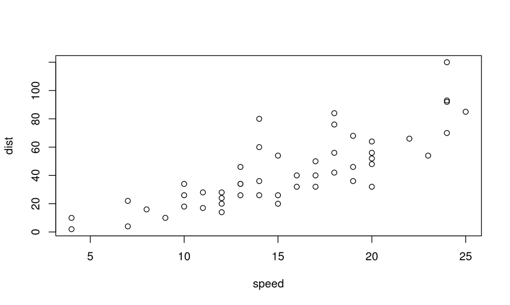